# Next-generation sequencing - analysis with DESeq2

Marc Bender

2024-03-14

# Resources

For additional info on analysis workflows check: https://www.bioconductor.org/packages/release/bioc/vignettes/DESeq2/inst/doc/DESeq2.html https://bioconductor.org/packages/release/workflows/vignettes/rnaseqGene/inst/doc/rnaseqGene.html  
https://www.bigbioinformatics.org/r-and-rnaseq-analysis https://github.com/bigbioinformatics/r-programming-and-rnaseq-workshop

# Thresholds, design formula and number of transcripts

```r
## always specify this filter criterion to take the desired difference into account in significance testing
pThres            <- 0.05
lfcThres          <- round(log2(1.5),4)
minimumCount      <- 10 # Here we perform pre-filtering to keep only rows that have a count of at least 10 for a
                        # minimal number of samples. The count of 10 is a reasonable choice for bulk RNA-seq.
smallestGroupSize <- 4  # A recommendation for the minimal number of samples is to specify the smallest group
                        # size,e.g. here there are 4 samples in each group.
factor1 <- "dex"
factor2 <- "cell"
```

```r
keep <- rowSums(counts(dds) >= 10) >= smallestGroupSize
dds <- dds[keep,]
```

```r
data.frame(Thresholds = NA, pThres, lfcThres, minimumCount, smallestGroupSize, formula = paste(as.character(contrast), collapse = ""),
           Transcripts = NA, n_total = nrow(assay(dat)), n_expr = nrow(assay(dds))) %>%
  gather(rownames, value) %>%
  mutate(rownames = factor(rownames, levels = c("Thresholds", "pThres", "lfcThres", "minimumCount", "smallestGroupSize",
                                                "formula", "Transcripts", "n_total", "n_expr"), labels = c("Thresholds", "P-value", "Log-fold change", "Minimum read count", "Smallest group size",
                                                "Design Formula", "Transcript number", "Total number of transcripts", "Filtered number of transcripts"))) %>%
  flextable() %>%
  set_header_labels(rownames = "", value = "Value") %>%
  bold(part = "header") %>%
  bold(i = c(1,6,7), j = 1) %>%
  padding(i = c(2,3,4,5,8,9), j = 1, padding.left = 10)%>%
  line_spacing(space = 0.4, part = "body") %>%
  footnote(i = 9, j = 1,
            value = as_paragraph(
              c("All transcripts which are above the minimum read count threshold.")
            ),
            ref_symbols = c("\u2020"),
            part = "body") %>%
  fontsize(size = 9, part = "all") %>%
  autofit()
```

[output not shown]

# Exploratory data analysis

## Heatmap of Poisson distances between samples

- IMPORTANT:
  - use Poisson distance for raw (non-normalized) count data
  - use Euclidean distance for data normalized by regularized-logarithm transformation (rlog) or variance stablization transfromation (vst)

```r
poisd <- PoissonDistance(t(counts(dds)))
samplePoisDistMatrix <- as.matrix( poisd$dd)
rownames(samplePoisDistMatrix) <- paste(dds$dex, dds$cell, sep=" - " )
colnames(samplePoisDistMatrix) <- NULL
colors = colorRampPalette( rev(RColorBrewer::brewer.pal(9, "Blues")) )(255)
pheatmap(samplePoisDistMatrix,
         clustering_distance_rows = poisd$dd,
         clustering_distance_cols = poisd$dd,
         col = colors)
```

[output not shown]

## Transform data

Which transformation to choose? The VST is much faster to compute and is less sensitive to high count outliers than the rlog. The rlog tends to work well on small datasets (n < 30), potentially outperforming the VST when there is a wide range of sequencing depth across samples (an order of magnitude difference). We therefore recommend the VST for medium-to-large datasets (n > 30). You can perform both transformations and compare the meanSdPlot or PCA plots generated, as described below.

To show the effect of the transformation, in the figure below we plot the first sample against the second, first simply using the log2 function (after adding 1, to avoid taking the log of zero), and then using the VST and rlog-transformed values. For the log2 approach, we need to first estimate size factors to account for sequencing depth, and then specify normalized=TRUE. Sequencing depth correction is done automatically for the vst and rlog.

```r
# variance stabilized transformation
vsd <- vst(dds, blind = FALSE)

# rlog transformation (regularized log transformation)
rld <- rlog(dds, blind = FALSE)

# estimate size factors
dds <- estimateSizeFactors(dds)
```

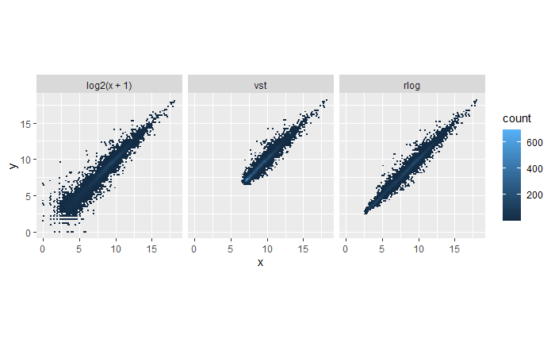

```r
# build data set
df <- bind_rows(
  as_data_frame(log2(counts(dds, normalized=TRUE)[, 1:2]+1)) %>%
    mutate(transformation = "log2(x + 1)"),
  as_data_frame(assay(vsd)[, 1:2]) %>% mutate(transformation = "vst"),
  as_data_frame(assay(rld)[, 1:2]) %>% mutate(transformation = "rlog"))

# assign column names
colnames(df)[1:2] <- c("x", "y")

# transform to factor
lvls <- c("log2(x + 1)", "vst", "rlog")
df$transformation <- factor(df$transformation, levels=lvls)

# plot values
ggplot(df, aes(x = x, y = y)) + geom_hex(bins = 80) +
  coord_fixed() + facet_grid( . ~ transformation)
```

## Principal component analysis (PCA)

Die Hauptkomponentenanalyse oder *principal component analysis* (PCA) ist ein Verfahren zur Reduktion der Datendimensionalität und findet Anwendung bei komplexen Datensätzen (aus n Proben mit p gemessenen Merkmalen), um Muster oder Strukturen in den Daten zu erkennen und die Interpretation der Daten zu vereinfachen. Dies erfolgt durch Identifikation neuer unkorrelierter Variablen, den sog. Hauptkomponenten (PC = *principal component*), welche sukzessive die erklärte Varianz innerhalb eines Datensets maximieren. Die Berechnung dieser Hauptkomponenten erfolgt dabei durch Zentrieren der Daten und einen nachfolgenden iterativen Prozess, bei dem eine zufällige Gerade durch den Mittelwert der Datenpunkte gelegt und so lange rotiert wird, bis der Abstand der auf die Gerade projizierten Datenpunkte zum Zentrum maximal ist. Die Distanzen werden berechnet als:

$$\begin{align*}
SS(distances) = d^2_{1} + d^2_{2} + ... + d^2_{n}
\end{align*}$$

mit SS(distances) = Eigenwert (Quadratsumme der Distanzen), d = Distanz vom projizierten Datenpunkt zum Zentrum, n = Probengröße.

Die Gerade mit dem größten Eigenwert wird als PC1 bezeichnet und trägt am meisten zur Varianzaufklärung bei. Im Anschluss wird die nächste Gerade gesucht, die orthogonal zur ersten Gerade ist und ebenfalls durch den Mittelwert der Datenpunkte verläuft. Nach diesem Grundsatz können (bis zur n-ten Hauptkomponente) weitere Hauptkomponenten gefunden werden, wobei diese stets orthogonal zu den bisherigen Hauptkomponenten stehen müssen.

Die Reduktion der Dimensionalität beruht darauf, dass die jeweiligen Hauptkomponenten einen unterschiedlich großen (absteigend von PC1 zu PCn) Anteil der Datenvarianz erklären und es daher in den meisten Fällen ausreicht die ersten drei Hauptkomponenten zu analysieren (welche jeweils als 2-dimensionaler Plot gegeneinander aufgetragen werden), um Gemeinsamkeiten innerhalb der Proben zu identifizieren.  
Der Anteil der Varianz, der durch die jeweilige Hauptkomponente erklärt wird ($var_{explained}$), kann anhand folgender Formel berechnet werden:

$$\begin{align*}
var(PC_{i}) = \frac{SS(distances (PC_{i}))}{n-1}
\end{align*}$$

$$\begin{align*}
var_{explained} = \frac{var(PC_{i})}{\sum^{n}_{j=1}var(PC_{j})}
\end{align*}$$

mit $PC_{i}$ = Hauptkomponente i.

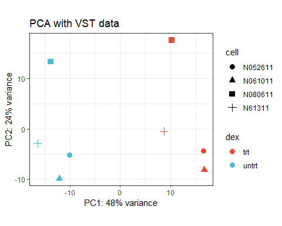

```r
###
# plot PCA
pcaData <- plotPCA(vsd, intgroup = c(factor1, factor2), returnData = TRUE)
percentVar <- round(100 * attr(pcaData, "percentVar"))

# plot data with ggplot
ggplot(pcaData, aes_string(x = "PC1", y = "PC2", color = factor1, shape = factor2)) +
  geom_point(size =3) +
  xlab(paste0("PC1: ", percentVar[1], "% variance")) +
  ylab(paste0("PC2: ", percentVar[2], "% variance")) +
  coord_fixed() +
  ggtitle("PCA with VST data") +
  theme_bw() +
  ggsci::scale_color_npg()
```

# Differential expression analysis

```r
dds <- DESeq(dds)
```

## Volcano Plot

```r
# 5. Get the results and plot Volcano plot without filter within results function
res_volcano <- results(dds)

### annotate genes
# for all genes
anno <- AnnotationDbi::select(org.Hs.eg.db, rownames(res_volcano),
                              columns=c("ENSEMBL", "ENTREZID", "SYMBOL", "GENENAME"),
                              keytype="ENSEMBL")

# adding ENSEMBL gene ID as a column in significant differentially expression gene table.
dat_volcano <- cbind(ENSEMBL = rownames(res_volcano), res_volcano)
dat_volcano <- left_join(as.data.frame(dat_volcano), anno)

# plot Volcano
# this only serves as diagnostic and representation tool. the actual fold change thresholds and pvalues change later due to the way the results function works
EnhancedVolcano(as.data.frame(dat_volcano), lab = dat_volcano$SYMBOL,
                x = 'log2FoldChange', y = 'padj', gridlines.major = FALSE, gridlines.minor = FALSE,
                xlim = c(-8, 8), ylim = c(-5, 150), title = 'Treated vs untreated',
                pCutoff = pThres, FCcutoff = lfcThres, pointSize = 1.5, labSize = 4)
```

[output not shown]

## MA plot

An MA-plot (Dudoit et al. 2002) provides a useful overview for the distribution of the estimated coefficients in the model, e.g. the comparisons of interest, across all genes. On the y-axis, the “M” stands for “minus” – subtraction of log values is equivalent to the log of the ratio – and on the x-axis, the “A” stands for “average”. You may hear this plot also referred to as a mean-difference plot, or a Bland-Altman plot.

Before making the MA-plot, we use the lfcShrink function to shrink the log2 fold changes for the comparison of dex treated vs untreated samples. There are three types of shrinkage estimators in DESeq2, which are covered in the DESeq2 vignette. Here we specify the apeglm method for shrinking coefficients, which is good for shrinking the noisy LFC estimates while giving low bias LFC estimates for true large differences (Zhu, Ibrahim, and Love 2018). To use apeglm we specify a coefficient from the model to shrink, either by name or number as the coefficient appears in resultsNames(dds).

WARNING: DO NOT ALWAYS SHRINK EVERYTHING BY DEFAULT. Look at MA plot and Volcano plot to see if it makes sense.

```r
### plot MA plot

res <- results(dds, lfcThreshold = lfcThres, alpha = pThres)

# plot with original lfc
plotMA(res, ylim = c(-5, 5), main = "MA plot with original log fold changes")

# shrink estimates and exlpore differences in MA plots
resShrunk <- lfcShrink(dds, coef="dex_untrt_vs_trt", type="apeglm")
plotMA(resShrunk, ylim = c(-5, 5), main = "MA plot with shrunken log fold changes")

###
# WARNING: DO NOT ALWAS SHRINK EVERYTHING BY DEFAULT. Look at MA plot and Volcano plot to see if it makes sense
###
```

[output not shown]

```r
anno <- AnnotationDbi::select(org.Hs.eg.db, rownames(res),
                              columns=c("ENSEMBL", "ENTREZID", "SYMBOL", "GENENAME"),
                              keytype="ENSEMBL")
#remove duplicated ENSEMBL ID entries
anno <- anno %>% filter(!duplicated(ENSEMBL))

# adding ENSEMBL gene ID as a column in significant differentially expression gene table.
allRes <- cbind(ENSEMBL = rownames(res), res)
allRes <- if(dim(anno)[1] == dim(allRes)[1]){
  left_join(as.data.frame(allRes), anno)
} else {
  stop("Dimensions of annotation object and result object are different.")
}

# subset significant results
sigRes <- subset(allRes, padj < pThres)
```

## Heatmap

If using either of Euclidean distance or Pearson correlation, data should follow a Gaussian / normal (parametric) distribution. So, if coming from a microarray, anything from RMA normalisation is fine, whereas, if coming from RNA-seq, any data deriving from a transformed normalised count metric should be fine, such as variance-stabilised, regularised log, or log CPM expression levels.

If you are performing clustering on non-normal data, like ‘normalised’ [non-transformed] RNA-seq counts, FPKM expression units, etc., then use Spearman correlation (non-parametric).

```r
nGenes <- 100
topSignif <- head(order(allRes$padj, decreasing = FALSE),nGenes)
labels <- allRes[topSignif,]$SYMBOL
mat  <- assay(vsd)[topSignif, ]
annoHeatmap <- as.data.frame(colData(vsd)[, c("cell","dex")])
pheatmap(mat, annotation_col = annoHeatmap, labels_row = labels, scale = "row", clustering_distance_rows = "correlation",
         main= paste("Top ",nGenes," differentially expressed genes", sep =""))
```

[output not shown]

```r
# Heatmap of all DE genes
mat <- assay(vsd)[sigRes$ENSEMBL,]
annoHeatmap <- as.data.frame(colData(rld)[, c("cell","dex")])
pheatmap(mat, scale = "row", show_rownames = FALSE, clustering_distance_rows = "correlation",
         annotation_col = annoHeatmap, main="Differentially Expressed genes")
```

[output not shown]